# Chap7_1

J.H AHN

2021 12 16

## 7.1 The linear model

### Simple linear regression

가장 간단한 케이스로 회귀 모델은 예측변수(forecast variable) $y$와 하나의 예측변수 $x$ 사이에서 만들어지는 선형 관계이다.

$$y_t = \beta_0 + \beta_1 x_t + \varepsilon_t$$

아래 Fig 7.1에서 보는 것과 같이 Coefficient $\beta_0$와 $\beta_1$은 각각 선의 절편과 기울기를 나타낸다.  
절편(intercept) $\beta_0$는 $x=0$일 때 $y$값을 나타내고 기울기 $\beta_1$은 $x$값이 한 단위 증가할 때 $y$가 얼마나 변하는지 평균적으로 예측되는 값을 나타낸다.

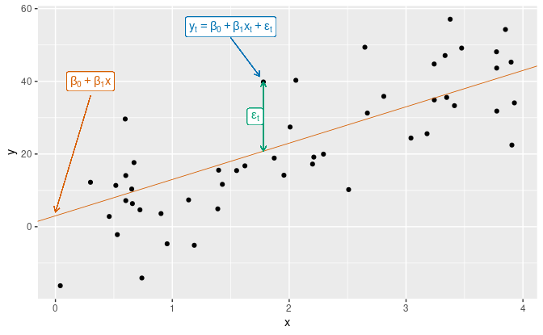

Fig7.1

중요한 것은 관측치가 직선 위에 있는 것이 아닌 그 주변에 흩어져있다는 사실이다.  
각 관측치 $y_t$는 $\beta_0 + \beta_1 x_t$와 무작위 오차(error)인 $\varepsilon_t$로 구성된 것으로 생각할 수 있다. 여기서 **오차(error)**는 실수를 의미하는 것이 아니라 기본이 되는 직선(the underlying straight line)과의 편차를 의미한다. 이 오차는 $x_t$외에 $y_t$에 영향을 줄 수 있는 모든 것을 담고 있다.

### Example: US consumption expenditure

Fig 7.2에는 분기별 소비지출 변화(성장률)를 시계열로 나타낸 것이다.  
$y$는 개인 소비지출 변화량, $x$는 개안별 가처분 소득이며, 1970년 1분기에서 2019년 2분기까지이다.

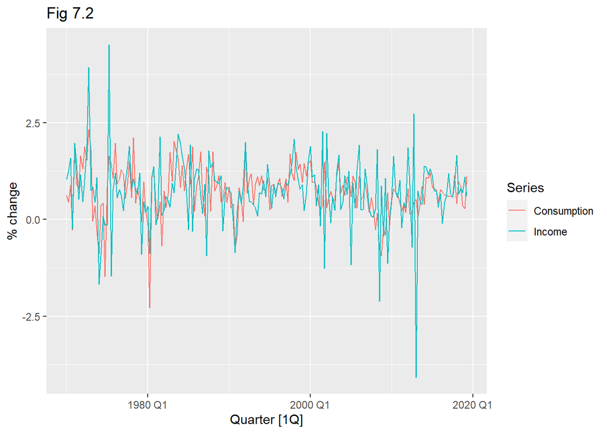

```r
us_change %>%
    pivot_longer(c(Consumption, Income), names_to = "Series") %>%
    autoplot(value) +
    labs(y = "% change", title = "Fig 7.2")
```

수입 변화에 대한 소비 변화를 나타낸 Scatter plot은 Fig 7.3에서 예상 회귀선과 함께 볼 수 있다.

$$\hat{y}_t=0.54 + 0.27x_t$$

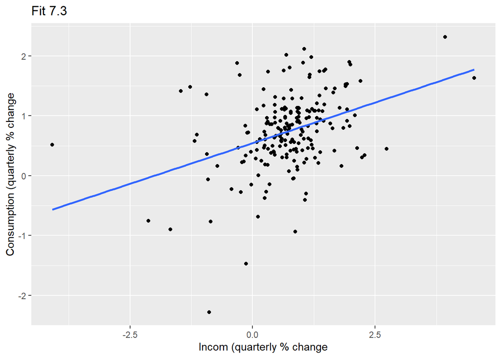

```r
us_change %>%
    ggplot(aes(x = Income, y = Consumption)) +
    geom_point() +
    geom_smooth(method = "lm", se = FALSE) +
    labs(title = "Fit 7.3",
         x = "Incom (quarterly % change",
         y = "Consumption (quarterly % change")
```

추세식은 `TSLM()`함수를 이용해서 추정해 볼 수 있다.

```r
us_change %>%
    model(TSLM(Consumption ~ Income)) %>%
    report()
```

```
## Series: Consumption
## Model: TSLM
##
## Residuals:
##      Min       1Q   Median       3Q      Max
## -2.58236 -0.27777  0.01862  0.32330  1.42229
##
## Coefficients:
##             Estimate Std. Error t value Pr(>|t|)
## (Intercept)  0.54454    0.05403  10.079  < 2e-16 ***
## Income       0.27183    0.04673   5.817  2.4e-08 ***
## ---
## Signif. codes:  0 '***' 0.001 '**' 0.01 '*' 0.05 '.' 0.1 ' ' 1
##
## Residual standard error: 0.5905 on 196 degrees of freedom
## Multiple R-squared: 0.1472,  Adjusted R-squared: 0.1429
## F-statistic: 33.84 on 1 and 196 DF, p-value: 2.4022e-08
```

`TSLM()`함수는 Chap7_2에서 상세하게 다룰 것이다.

절편을 해석하려면 $x=0$값이 의미가 있어야 한다. 이 경우 $x=0$일 때 (즉 지난 분기 이후 개인 가처분 소득의 변화가 없을 때) $y$의 예측값은 0.54(즉 개인 소비지출의 평균 증가율이 0.54%)이다.  
$x=0$이 의미가 없더라도 절편은 모델에서 중요한 부분이다. 절편이 없으면 기울기가 불필요하게 왜곡될 수 있기 때문이다. 회귀선이 꼭 원점을 통과해야 하는 경우가 아니라면 절편은 꼭 포함되어야 한다.

### Multiple linear regression

둘 이상의 예측변수가 있을 때, 그 모델은 **다중 회귀 모델(multiple regression model)**이라 한다. 다중 회귀 모델의 일반적인 형태는 아래와 같다.

$$\begin{equation}
y_t = \beta_{0} + \beta_{1} x_{1,t} + \beta_{2} x_{2,t} + \cdots + \beta_{k} x_{k,t} + \varepsilon_t,
\tag{7.1}
\end{equation}$$

여기서 $y$는 예측할 변수이고 $x_{1},\dots,x_{k}$는 $k$개의 예측변수이다. 각 예측 변수는 숫자여야 한다. coefficient(계수) $\beta_{1},\dots,\beta_{k}$는 모델에 있는 다른 모든 예측 변수의 효과를 고려한 후 각 예측 변수의 효과를 측정한다. 따라서 계수는 예측변수의 한계효과(marginal effects)를 측정한다.

### Example: US consumption expenditure

Fig 7.4에는 예측 변수를 추가 하는 것이 예측에 유용하다는 것을 보여준다. 추가된 예측변수들은 산업 생산 및 개인 저출의 분기별 백분율 변화와 실업률의 분기별 변화이다. 예측변수를 추가하여 다중선형 예측 변수를 만들면 소비 지출이 개인 소득 뿐만 아니라 다른 예측변수로부터 받는 영향도 고려되므로 더 정확한 예측을 할 수 있다.

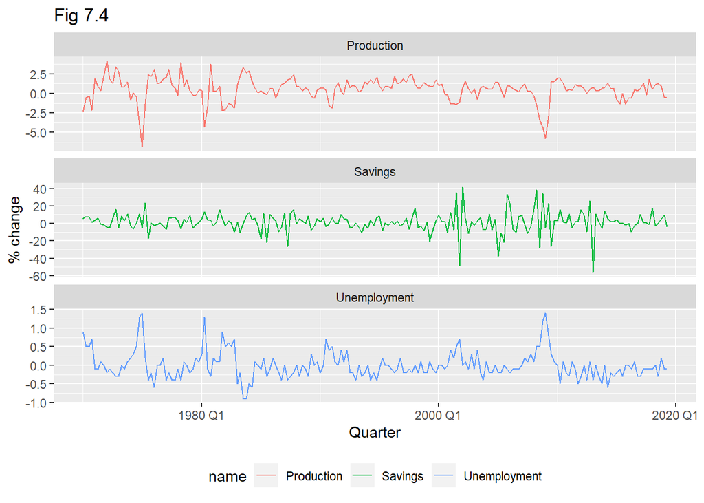

```r
us_change %>%
    select(-Consumption, -Income) %>%
    pivot_longer(-Quarter) %>%
    ggplot(aes(x = Quarter, y = value, color = name)) +
    geom_line() +
    facet_wrap(~name, scales = "free_y", ncol = 1) +
    labs(title = "Fig 7.4", y = "% change") +
    theme(legend.position = "bottom")
```

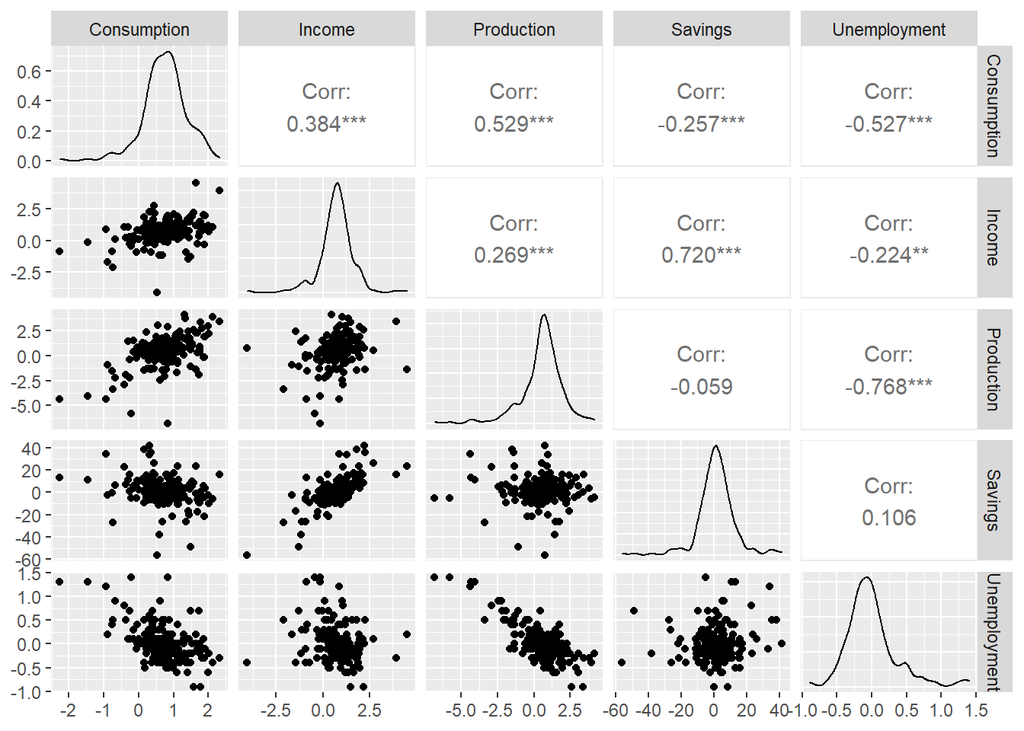

```r
us_change %>%
    GGally::ggpairs(columns = 2:6)
```

### Assumptions

선형회귀모델을 사용할 때 Eq 7.1의 변수에 대해 몇 가지 가정을 한다.

첫째, 우리는 모델이 현실에 대한 합리적인 근사치라고 가정한다. 즉 forecast variable과 predictor variable간의 관계가 이 선형 방정식을 충족한다고 본다.

둘째, 오차($(\varepsilon_{1},\dots,\varepsilon_{T})$)에 대해 다음과 같은 가정을 한다.

*오차는 평균이 0이다. 그렇지 않다면 Error값은 systematically biased 된다.

*오차는 자기상관(autocorrelated)이 없다. 자기상관성이 있을 경우 데이터에서 남은 정보가 더 있다는 의미이고 이는 예측의 효율성을 떨어뜨린다.

*오차는 predictor variable과 관련이 없다. 관련이 있다면 모델에 반영되어야 할 정보가 남아있다는 뜻이다.

예측 구간을 쉽게 생성하기 위해 오차가 일정한 분산 $\sigma^2$으로 정규분포 되도록 하는 것이 유용하다.

선형 회귀 모델의 또 다른 중요한 가정은 predictor $x$가 확률변수가 아니라는 것이다. 실험실에서 통제된 실험을 수행하는 경우 각 $x$값을 제어할 수 있고 (따라서 무작위가 아님) 그에 따른 결과값 $y$를 관찰할 수 있다. 관찰데이터를 사용하면 $x$값을 제어할 수 없고 단순히 관찰만 가능하다. 따라서 우리는 $x$(predictor)는 관찰만 가능한 것이라고 가정한다.